# EasyVisa_Full_Code_Notebook_final

## Problem Statement

### Business Context

Business communities in the United States are facing high demand for human resources, but one of the constant challenges is identifying and attracting the right talent, which is perhaps the most important element in remaining competitive. Companies in the United States look for hard-working, talented, and qualified individuals both locally as well as abroad.

The Immigration and Nationality Act (INA) of the US permits foreign workers to come to the United States to work on either a temporary or permanent basis. The act also protects US workers against adverse impacts on their wages or working conditions by ensuring US employers' compliance with statutory requirements when they hire foreign workers to fill workforce shortages. The immigration programs are administered by the Office of Foreign Labor Certification (OFLC).

OFLC processes job certification applications for employers seeking to bring foreign workers into the United States and grants certifications in those cases where employers can demonstrate that there are not sufficient US workers available to perform the work at wages that meet or exceed the wage paid for the occupation in the area of intended employment.

### Objective

In FY 2016, the OFLC processed 775,979 employer applications for 1,699,957 positions for temporary and permanent labor certifications. This was a nine percent increase in the overall number of processed applications from the previous year. The process of reviewing every case is becoming a tedious task as the number of applicants is increasing every year.

The increasing number of applicants every year calls for a Machine Learning based solution that can help in shortlisting the candidates having higher chances of VISA approval. OFLC has hired the firm EasyVisa for data-driven solutions. You as a data scientist at EasyVisa have to analyze the data provided and, with the help of a classification model:

- Facilitate the process of visa approvals.
- Recommend a suitable profile for the applicants for whom the visa should be certified or denied based on the drivers that significantly influence the case status.

### Data Description

The data contains the different attributes of employee and the employer. The detailed data dictionary is given below.

- case_id: ID of each visa application
- continent: Information of continent the employee
- education_of_employee: Information of education of the employee
- has_job_experience: Does the employee has any job experience? Y= Yes; N = No
- requires_job_training: Does the employee require any job training? Y = Yes; N = No
- no_of_employees: Number of employees in the employer's company
- yr_of_estab: Year in which the employer's company was established
- region_of_employment: Information of foreign worker's intended region of employment in the US.
- prevailing_wage: Average wage paid to similarly employed workers in a specific occupation in the area of intended employment. The purpose of the prevailing wage is to ensure that the foreign worker is not underpaid compared to other workers offering the same or similar service in the same area of employment.
- unit_of_wage: Unit of prevailing wage. Values include Hourly, Weekly, Monthly, and Yearly.
- full_time_position: Is the position of work full-time? Y = Full Time Position; N = Part Time Position
- case_status: Flag indicating if the Visa was certified or denied

## Installing and Importing the necessary libraries

```python
# Installing the libraries with the specified version.
!pip install numpy==1.25.2 pandas==1.5.3 scikit-learn==1.5.2 matplotlib==3.7.1 seaborn==0.13.1 xgboost==2.0.3 -q --user
```

**Note**: *After running the above cell, kindly restart the notebook kernel and run all cells sequentially from the below.*

```python
import numpy as np
import pandas as pd
import matplotlib.pyplot as plt
import seaborn as sns

from sklearn.model_selection import train_test_split, StratifiedKFold, cross_val_score
from sklearn.preprocessing import StandardScaler, LabelEncoder
from sklearn.metrics import accuracy_score, recall_score, precision_score, f1_score, confusion_matrix
from sklearn.model_selection import GridSearchCV

from sklearn.tree import DecisionTreeClassifier
from sklearn.ensemble import RandomForestClassifier, BaggingClassifier, AdaBoostClassifier, GradientBoostingClassifier
from xgboost import XGBClassifier

from imblearn.over_sampling import SMOTE
from imblearn.under_sampling import RandomUnderSampler

from google.colab import drive
```

## Import Dataset

```python
drive.mount('/content/drive')
file_path = '/content/drive/My Drive/Colab Notebooks/EasyVisa.csv'
df = pd.read_csv(file_path)
```

## Overview of the Dataset

#### View the first and last 5 rows of the dataset

```python
print("Display the first 5 rows:")
print(df.head())

print("\nDisplay the last 5 rows:")
print(df.tail())
```

```
Display the first 5 rows:
  case_id continent education_of_employee has_job_experience  \
0  EZYV01      Asia           High School                  N
1  EZYV02      Asia              Master's                  Y
2  EZYV03      Asia            Bachelor's                  N
3  EZYV04      Asia            Bachelor's                  N
4  EZYV05    Africa              Master's                  Y

  requires_job_training  no_of_employees  yr_of_estab region_of_employment  \
0                     N            14513         2007                 West
1                     N             2412         2002            Northeast
2                     Y            44444         2008                 West
3                     N               98         1897                 West
4                     N             1082         2005                South

```

[output cut: 35 more lines]

#### Understand the shape of the dataset

```python
print("Shape of the dataset:", df.shape)
```

```
Shape of the dataset: (25480, 12)
```

#### Check the data types of the columns for the dataset

```python
print("Data types of the columns:")
print(df.info())
```

```
Data types of the columns:
<class 'pandas.core.frame.DataFrame'>
RangeIndex: 25480 entries, 0 to 25479
Data columns (total 12 columns):
 #   Column                 Non-Null Count  Dtype
---  ------                 --------------  -----
 0   case_id                25480 non-null  object
 1   continent              25480 non-null  object
 2   education_of_employee  25480 non-null  object
 3   has_job_experience     25480 non-null  object
 4   requires_job_training  25480 non-null  object
 5   no_of_employees        25480 non-null  int64
 6   yr_of_estab            25480 non-null  int64
 7   region_of_employment   25480 non-null  object
 8   prevailing_wage        25480 non-null  float64
 9   unit_of_wage           25480 non-null  object
 10  full_time_position     25480 non-null  object
 11  case_status            25480 non-null  object
dtypes: float64(1), int64(2), object(9)
memory usage: 2.3+ MB
None
```

## Exploratory Data Analysis (EDA)

#### Let's check the statistical summary of the data

```python
print("Statistical summary:")
print(df.describe(include='all'))
```

```
Statistical summary:
       case_id continent education_of_employee has_job_experience  \
count    25480     25480                 25480              25480
unique   25480         6                     4                  2
top     EZYV01      Asia            Bachelor's                  Y
freq         1     16861                 10234              14802
mean       NaN       NaN                   NaN                NaN
std        NaN       NaN                   NaN                NaN
min        NaN       NaN                   NaN                NaN
25%        NaN       NaN                   NaN                NaN
50%        NaN       NaN                   NaN                NaN
75%        NaN       NaN                   NaN                NaN
max        NaN       NaN                   NaN                NaN

       requires_job_training  no_of_employees   yr_of_estab  \
count                  25480     25480.000000  25480.000000
unique                     2              NaN           NaN
top                        N              NaN           NaN
freq                   22525              NaN           NaN
mean                     NaN      5667.043210   1979.409929
std                      NaN     22877.928848     42.366929
min                      NaN       -26.000000   1800.000000
25%                      NaN      1022.000000   1976.000000
50%                      NaN      2109.000000   1997.000000
75%                      NaN      3504.000000   2005.000000
max                      NaN    602069.000000   2016.000000

       region_of_employment  prevailing_wage unit_of_wage full_time_position  \
count                 25480     25480.000000        25480              25480
unique                    5              NaN            4                  2
top               Northeast              NaN         Year                  Y
freq                   7195              NaN        22962              22773
mean                    NaN     74455.814592          NaN                NaN
std                     NaN     52815.942327          NaN                NaN
min                     NaN         2.136700          NaN                NaN
25%                     NaN     34015.480000          NaN                NaN
50%                     NaN     70308.210000          NaN                NaN
75%                     NaN    107735.512500          NaN                NaN
max                     NaN    319210.270000          NaN                NaN

       case_status
count        25480
unique           2
top      Certified
freq         17018
mean           NaN
std            NaN
min            NaN
25%            NaN
50%            NaN
75%            NaN
max            NaN
```

#### Fixing the negative values in number of employees columns

```python
# Convert negative 'no_of_employees' to positive
df['no_of_employees'] = df['no_of_employees'].abs()

print("Statistical summary of 'no_of_employees' after fix:")
print(df['no_of_employees'].describe())
```

```
Statistical summary of 'no_of_employees' after fix:
count     25480.000000
mean       5667.089207
std       22877.917453
min          11.000000
25%        1022.000000
50%        2109.000000
75%        3504.000000
max      602069.000000
Name: no_of_employees, dtype: float64
```

#### Let's check the count of each unique category in each of the categorical variables

```python
categ_cols = df.select_dtypes(include='object').columns

for col in categ_cols:
    print(f"\nValue counts for column: {col}")
    print(df[col].value_counts())
```

```
Value counts for column: case_id
EZYV01       1
EZYV16995    1
EZYV16993    1
EZYV16992    1
EZYV16991    1
            ..
EZYV8492     1
EZYV8491     1
EZYV8490     1
EZYV8489     1
EZYV25480    1
Name: case_id, Length: 25480, dtype: int64

Value counts for column: continent
Asia             16861
Europe            3732
North America     3292
South America      852
Africa             551
Oceania            192
Name: continent, dtype: int64

Value counts for column: education_of_employee
Bachelor's     10234
Master's        9634
High School     3420
Doctorate       2192
Name: education_of_employee, dtype: int64

Value counts for column: has_job_experience
Y    14802
N    10678
Name: has_job_experience, dtype: int64

Value counts for column: requires_job_training
N    22525
Y     2955
Name: requires_job_training, dtype: int64

```

[output cut: 9 more lines]

```
Year     22962
Hour      2157
Week       272
Month       89
Name: unit_of_wage, dtype: int64

Value counts for column: full_time_position
Y    22773
N     2707
Name: full_time_position, dtype: int64

Value counts for column: case_status
Certified    17018
Denied        8462
Name: case_status, dtype: int64
```

### Univariate Analysis

```python
def histogram_boxplot(data, feature, figsize=(15, 10), kde=False, bins=None):
    """
    Boxplot and histogram combined

    data: dataframe
    feature: dataframe column
    figsize: size of figure (default (15,10))
    kde: whether to show the density curve (default False)
    bins: number of bins for histogram (default None)
    """
    f2, (ax_box2, ax_hist2) = plt.subplots(
        nrows=2,  # Number of rows of the subplot grid= 2
        sharex=True,  # x-axis will be shared among all subplots
        gridspec_kw={"height_ratios": (0.25, 0.75)},
        figsize=figsize,
    )  # creating the 2 subplots
    sns.boxplot(
        data=data, x=feature, ax=ax_box2, showmeans=True, color="violet"
    )  # boxplot will be created and a triangle will indicate the mean value of the column
    sns.histplot(
        data=data, x=feature, kde=kde, ax=ax_hist2, bins=bins
    ) if bins else sns.histplot(
        data=data, x=feature, kde=kde, ax=ax_hist2
    )  # For histogram
    ax_hist2.axvline(
        data[feature].mean(), color="green", linestyle="--"
    )  # Add mean to the histogram
    ax_hist2.axvline(
        data[feature].median(), color="black", linestyle="-"
    )  # Add median to the histogram
```

```python
# function to create labeled barplots


def labeled_barplot(data, feature, perc=False, n=None):
    """
    Barplot with percentage at the top

    data: dataframe
    feature: dataframe column
    perc: whether to display percentages instead of count (default is False)
    n: displays the top n category levels (default is None, i.e., display all levels)
    """

    total = len(data[feature])  # length of the column
    count = data[feature].nunique()
    if n is None:
        plt.figure(figsize=(count + 1, 5))
    else:
        plt.figure(figsize=(n + 1, 5))

    plt.xticks(rotation=90, fontsize=15)
    ax = sns.countplot(
        data=data,
        x=feature,
        hue=feature,
        palette="Paired",
        order=data[feature].value_counts().index[:n].sort_values(),
    )

    for p in ax.patches:
        if perc == True:
            label = "{:.1f}%".format(
                100 * p.get_height() / total
            )  # percentage of each class of the category
        else:
            label = p.get_height()  # count of each level of the category

        x = p.get_x() + p.get_width() / 2  # width of the plot
        y = p.get_height()  # height of the plot

        ax.annotate(
            label,
            (x, y),
            ha="center",
            va="center",
            size=12,
            xytext=(0, 5),
            textcoords="offset points",
        )  # annotate the percentage

    plt.show()  # show the plot
```

#### Observations on education of employee

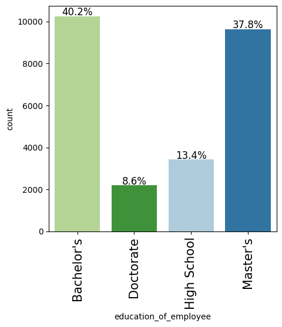

```python
labeled_barplot(df, 'education_of_employee', perc=True)
```

Observations on Employee Education Level:

Most visa applicants hold a Bachelor's degree, followed by those with a Master's or High School education. Doctorate degrees are the least common.

#### Observations on region of employment

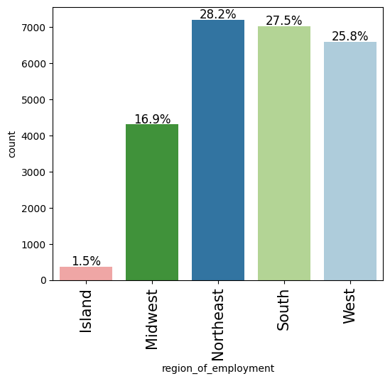

```python
labeled_barplot(df, 'region_of_employment', perc=True)
```

Observations on Region of Employment:

The 'Northeast' region is the most popular intended employment area, accounting for the highest percentage of visa applications at 28.2%, closely followed by the 'South' at 27.5%.

The 'West' region is also highly popular, with a very similar number of applications 25.8%.

The 'Midwest' region has a significantly lower number of applications, representing 16.9% of the total.

The 'Island' region is the least popular by a large margin, with only 1.5% of the total applications.